# Stats 506, F20, Problem Set 4

Zhihao Xu, xuzhihao@umich.edu

November 16, 2020

## About

This is the write-up solution to Problem Set 4 for Stats 506 in Fall 2020.

### Code Organization

- `ps4_q1.sas` consists of the `SAS` code used in Question 1. You need to create the `output/` folder before run. My `SAS` version is University Edition, the paths in the code are different from the path on the computer, which is start from `/folders/myfolders`. You need to change the path if it is running on other computer.
- `ps4_q2.sas` consists of the `SAS` code used in Question 2.
- `output` folder consists all the tables exported from `SAS`, which will be used in this write-up file for display.
- `ps4_writeup.Rmd` builds the page you are reading. Code for figures and tables can be found here.

## Question 1

**Click to view `SAS code for Question 1`.**

```
## /* ------------------------------------------------------------------------- *
##  * Problem Set 4, Question 1
##  * Stats 506, Fall 2020
##  *
##  * Describe your script here.
##  * This file is the SAS code for Problem Set 4, Question 1.
##  * Author: Zhihao Xu, xuzhihao@umich.edu
##  * ------------------------------------------------------------------------- */
##
## /* libnames:---------------------------------------------------------------- */
## libname hw4 '/folders/myfolders/hw4/';
## /* 79: --------------------------------------------------------------------- */
## /* recs09 */
## proc import
##      datafile = "/folders/myfolders/hw4/data/recs2009_public.csv"
##      out = recs09
##      replace;
##      delimiter = ',';
##      getnames = yes;
## run;
##
## /* recs2009 replicate weights data*/
## proc import
##      datafile = "/folders/myfolders/hw4/data/recs2009_public_repweights.csv"
##      out = brrwt09
##      replace;
##      delimiter = ',';
##      getnames = yes;
## run;
##
## /* create long weights for recs09: ----------------------------------------- */
## proc transpose data=brrwt09 out=brrwt_long09  prefix=brr_weight_ name=repl;
##      by DOEID;
##      var brr_weight_1-brr_weight_244;
## run;
##
## /* recs15 */
## proc import
##      datafile = "/folders/myfolders/hw4/data/recs2015_public_v4.csv"
##      out = recs15
```

[output cut: 351 more lines]

```
##  upr = dif + &m.*se;
## run;
##
## data recs_prop_dif;
##  set recs_prop_dif;
##  keep reginoc tvtype1 dif lwr upr;
## run;
##
## proc export data=recs_prop_dif
##  outfile='/folders/myfolders/hw4/output/ps4_q1_bii.csv'
##  dbms=csv
##  replace;
## run;
##
## /* 79: --------------------------------------------------------------------- */
```

1. Compare the average number of televisions (`TVCOLOR`) in US homes in 2009 and 2015 by Census Region

#### TV Number 2009

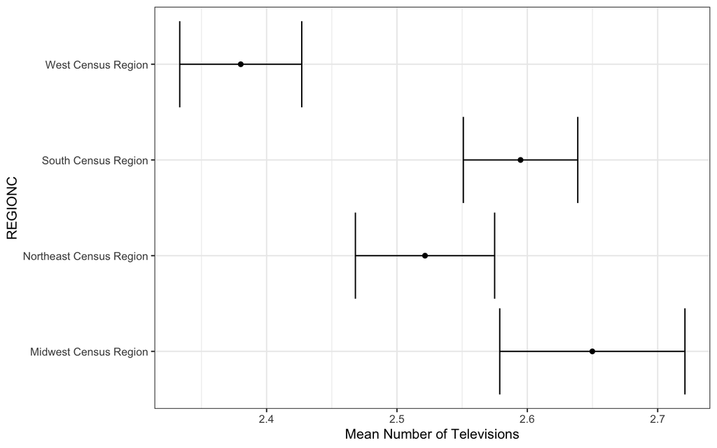

**Figure 1.** Average Number of TV in US Homes in 2009

#### TV Number 2015

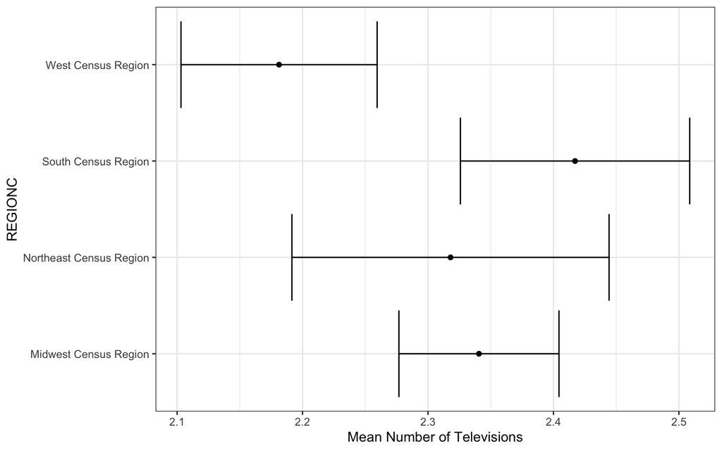

**Figure 2.** Average Number of TV in US Homes in 2015

#### Difference of TV Number from 2009 to 2015

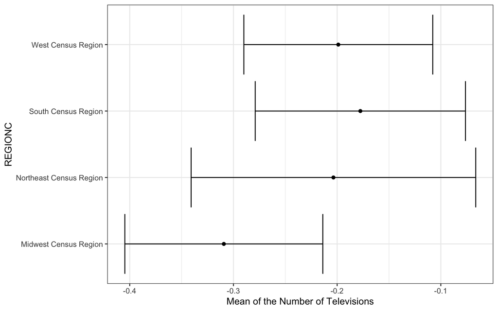

**Figure 3.** Difference of Average Number of TV in US Homes from 2009 to 2015

#### Estimate and Difference in Table

**Table 1.** Estimate Value of Average TV Number in US Homes for Both 2009 and 2015, and Their Difference

| Census Region | TV Number 2009 | TV Number 2015 | Difference |
| --- | --- | --- | --- |
| Northeast Census Region | 2.52 (2.47, 2.57) | 2.32 (2.19, 2.44) | -0.20 (-0.34, -0.07) |
| Midwest Census Region | 2.65 (2.58, 2.72) | 2.34 (2.28, 2.40) | -0.31 (-0.40, -0.21) |
| South Census Region | 2.59 (2.55, 2.64) | 2.42 (2.33, 2.51) | -0.18 (-0.28, -0.08) |
| West Census Region | 2.38 (2.33, 2.43) | 2.18 (2.10, 2.26) | -0.20 (-0.29, -0.11) |

2. Compare the proportion of primary televisions by display type for most used television (`TVTYPE1`) in US homes in 2009 and 2015 by Census Region

#### TV Type 2009

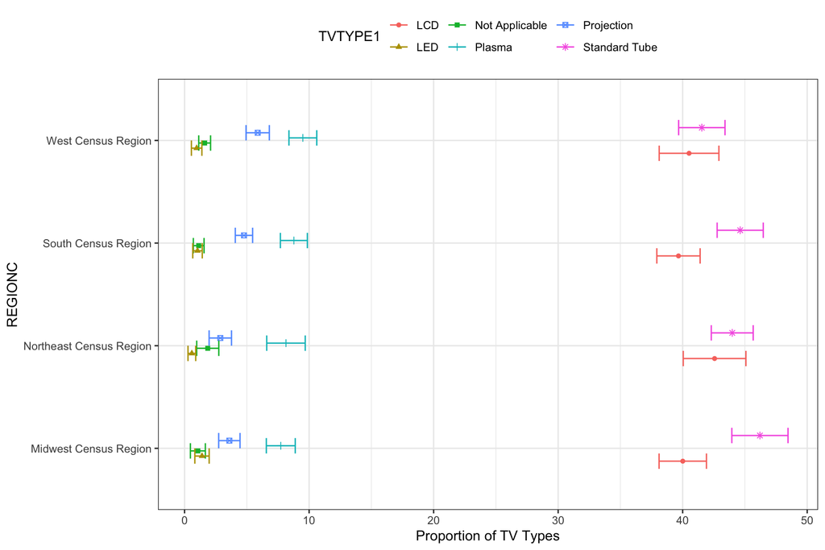

**Figure 4.** Proportion of Most Used TV in US Homes in 2009

#### TV Type 2015

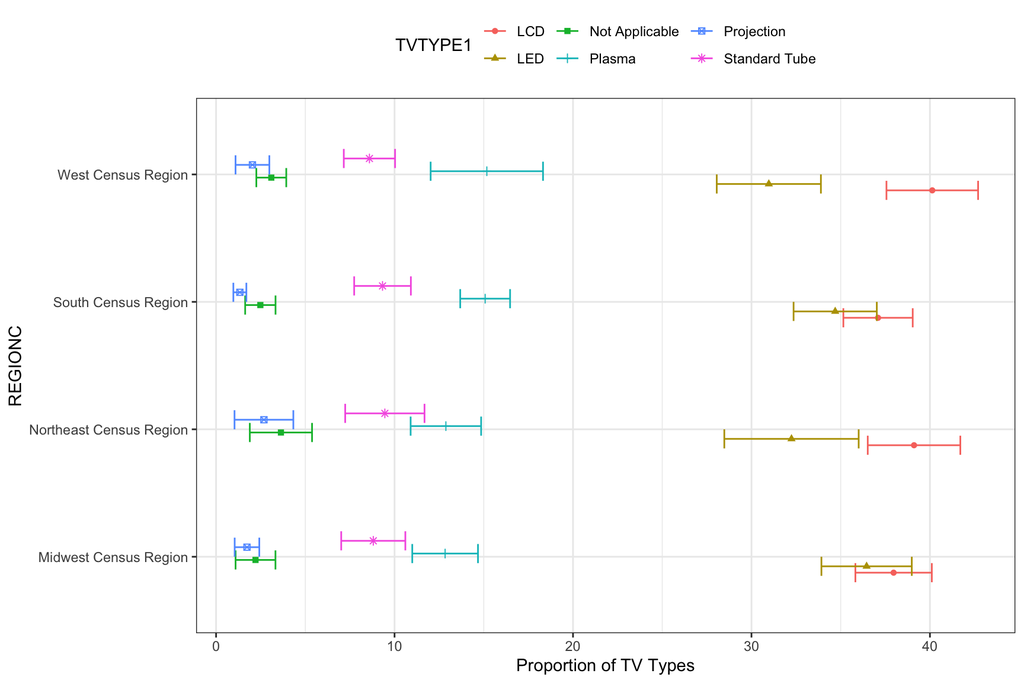

**Figure 5.** Proportion of Most Used TV in US Homes in 2015

#### Difference of TV Type from 2009 to 2015

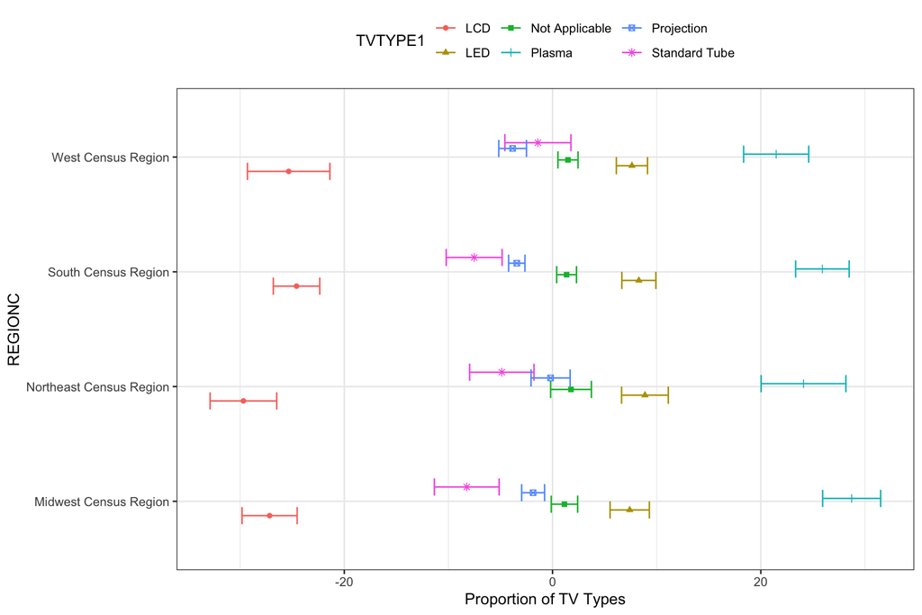

**Figure 6.** Difference in Proportion of Most Used TV in US Homes from 2009 to 2015

#### Estimate and Difference in Table

**Table 2.** Estimate Value of the Proportion of Most Used TV in US Homes for Both 2009 and 2015, and Their Difference

[output not shown]

## Question 2

**Click to view `SAS code for Question 2`.**

```
## /* ------------------------------------------------------------------------- *
##  * Problem Set 4, Question 2
##  * Stats 506, Fall 2020
##  *
##  * Describe your script here.
##  * This file is the SAS code for Problem Set 4, Question 2.
##  * Author: Zhihao Xu, xuzhihao@umich.edu
##  * ------------------------------------------------------------------------- */
##
## /* libnames:---------------------------------------------------------------- */
## libname hw4 '/folders/myfolders/hw4/';
## /* 79: --------------------------------------------------------------------- */
## /* demo */
## proc import
##      datafile = "/folders/myfolders/hw4/data/nhanes_demo.csv"
##      out = demo
##      replace;
##      delimiter = ',';
##      getnames = yes;
## run;
##
## /* ohxden */
## proc import
##      datafile = "/folders/myfolders/hw4/data/nhanes_ohxden.csv"
##      out = ohxden
##      replace;
##      delimiter = ',';
##      getnames = yes;
## run;
##
## data nhanes;
##  merge demo ohxden;
##  by SEQN;
##  ohx01pre = (OHX01TC = 2);
## run;
##
## proc logistic data= nhanes;
##  model ohx01pre = riagendr ridageyr ridageyr*ridageyr;
##  ods output
##      ParameterEstimates=pe
```

[output cut: 18 more lines]

```
##  outfile='/folders/myfolders/hw4/output/ps4_q2_2.csv'
##  dbms=csv
##  replace;
## run;
##
## proc export data=pe_w
##  outfile='/folders/myfolders/hw4/output/ps4_q2_3.csv'
##  dbms=csv
##  replace;
## run;
## proc export data=fs_w
##  outfile='/folders/myfolders/hw4/output/ps4_q2_4.csv'
##  dbms=csv
##  replace;
## run;
```

Here I just pick the first tooth `OHX01TC` as response.

| Logistics Regression without weight `proc logistic` | Logistics Regression with weight `proc surveylogistic` |
| --- | --- |
| Analysis of Maximum Likelihood Estimates | Analysis of Maximum Likelihood Estimates |
| Variable DF Estimate StdErr WaldChiSq ProbChiSq Intercept 1 4.46 0.08 2861.41 <.0001 RIAGENDR 1 0.43 0.03 181.65 <.0001 RIDAGEYR 1 -0.20 0.00 2799.04 <.0001 RIDAGEYR*RIDAGEYR 1 0.00 0.00 2520.74 <.000… | Variable DF Estimate StdErr WaldChiSq ProbChiSq Intercept 37398 3.72 0.09 1554.59 <.0001 RIAGENDR 37398 0.46 0.04 107.96 <.0001 RIDAGEYR 37398 -0.16 0.00 1181.23 <.0001 RIDAGEYR*RIDAGEYR 37398 0.00 0.… |
| Model Fit Statistics | Model Fit Statistics |
| RowId Criterion InterceptOnly InterceptAndCovariates AIC AIC 30437.85 25713.26 SBC SC 30446.42 25747.56 M2LOGL -2 Log L 30435.85 25705.26 | RowId Criterion InterceptOnly InterceptAndCovariates AIC AIC 1032170000 943380718 SBC SC 1032170000 943380793 M2LOGL -2 Log L 1032170000 943380710 |